# Risk Factor Analysis

## Outcome Variable

**Outcome Variable:** stunted

## Predictor Variables

**Intervention Variable:** impsan

**Adjustment Set:**

- arm
- sex
- W_mage
- meducyrs
- feducyrs
- hhwealth_quart
- hfoodsec
- W_mhtcm
- W_nrooms
- W_nchldlt5
- W_parity
- impfloor
- safeh20
- delta_W_mage
- delta_meducyrs
- delta_feducyrs
- delta_hhwealth_quart
- delta_hfoodsec
- delta_W_mhtcm
- delta_W_nrooms
- delta_W_nchldlt5
- delta_W_parity
- delta_impfloor
- delta_safeh20

## Stratifying Variables

The analysis was stratified on these variable(s):

- agecat
- studyid
- country

## Data Summary

| agecat | studyid | country | impsan | stunted | n_cell | n |
| --- | --- | --- | --- | --- | --- | --- |
| Birth | ki0047075b-MAL-ED | BANGLADESH | 0 | 0 | 32 | 234 |
| Birth | ki0047075b-MAL-ED | BANGLADESH | 0 | 1 | 5 | 234 |
| Birth | ki0047075b-MAL-ED | BANGLADESH | 1 | 0 | 164 | 234 |
| Birth | ki0047075b-MAL-ED | BANGLADESH | 1 | 1 | 33 | 234 |
| Birth | ki0047075b-MAL-ED | BRAZIL | 0 | 0 | 4 | 174 |
| Birth | ki0047075b-MAL-ED | BRAZIL | 0 | 1 | 0 | 174 |
| Birth | ki0047075b-MAL-ED | BRAZIL | 1 | 0 | 153 | 174 |
| Birth | ki0047075b-MAL-ED | BRAZIL | 1 | 1 | 17 | 174 |
| Birth | ki0047075b-MAL-ED | INDIA | 0 | 0 | 85 | 190 |
| Birth | ki0047075b-MAL-ED | INDIA | 0 | 1 | 13 | 190 |
| Birth | ki0047075b-MAL-ED | INDIA | 1 | 0 | 76 | 190 |
| Birth | ki0047075b-MAL-ED | INDIA | 1 | 1 | 16 | 190 |
| Birth | ki0047075b-MAL-ED | NEPAL | 0 | 0 | 1 | 171 |
| Birth | ki0047075b-MAL-ED | NEPAL | 0 | 1 | 0 | 171 |
| Birth | ki0047075b-MAL-ED | NEPAL | 1 | 0 | 152 | 171 |
| Birth | ki0047075b-MAL-ED | NEPAL | 1 | 1 | 18 | 171 |
| Birth | ki0047075b-MAL-ED | PERU | 0 | 0 | 167 | 250 |
| Birth | ki0047075b-MAL-ED | PERU | 0 | 1 | 21 | 250 |
| Birth | ki0047075b-MAL-ED | PERU | 1 | 0 | 54 | 250 |
| Birth | ki0047075b-MAL-ED | PERU | 1 | 1 | 8 | 250 |
| Birth | ki0047075b-MAL-ED | SOUTH AFRICA | 0 | 0 | 191 | 213 |
| Birth | ki0047075b-MAL-ED | SOUTH AFRICA | 0 | 1 | 20 | 213 |
| Birth | ki0047075b-MAL-ED | SOUTH AFRICA | 1 | 0 | 2 | 213 |
| Birth | ki0047075b-MAL-ED | SOUTH AFRICA | 1 | 1 | 0 | 213 |
| Birth | ki0047075b-MAL-ED | TANZANIA, UNITED REPUBLIC OF | 0 | 0 | 97 | 113 |
| Birth | ki0047075b-MAL-ED | TANZANIA, UNITED REPUBLIC OF | 0 | 1 | 16 | 113 |
| Birth | ki0047075b-MAL-ED | TANZANIA, UNITED REPUBLIC OF | 1 | 0 | 0 | 113 |
| Birth | ki0047075b-MAL-ED | TANZANIA, UNITED REPUBLIC OF | 1 | 1 | 0 | 113 |
| Birth | ki1017093-NIH-Birth | BANGLADESH | 0 | 0 | 18 | 28 |
| Birth | ki1017093-NIH-Birth | BANGLADESH | 0 | 1 | 1 | 28 |

[output cut: 166 more lines]

The following strata were considered:

- agecat: 24 months, studyid: ki0047075b-MAL-ED, country: BANGLADESH
- agecat: 24 months, studyid: ki0047075b-MAL-ED, country: BRAZIL
- agecat: 24 months, studyid: ki0047075b-MAL-ED, country: INDIA
- agecat: 24 months, studyid: ki0047075b-MAL-ED, country: NEPAL
- agecat: 24 months, studyid: ki0047075b-MAL-ED, country: PERU
- agecat: 24 months, studyid: ki0047075b-MAL-ED, country: SOUTH AFRICA
- agecat: 24 months, studyid: ki0047075b-MAL-ED, country: TANZANIA, UNITED REPUBLIC OF
- agecat: 24 months, studyid: ki1017093-NIH-Birth, country: BANGLADESH
- agecat: 24 months, studyid: ki1017093b-PROVIDE, country: BANGLADESH
- agecat: 24 months, studyid: ki1017093c-NIH-Crypto, country: BANGLADESH
- agecat: 24 months, studyid: ki1114097-CONTENT, country: PERU
- agecat: 24 months, studyid: ki1135781-COHORTS, country: GUATEMALA
- agecat: 24 months, studyid: ki1135781-COHORTS, country: INDIA
- agecat: 24 months, studyid: ki1135781-COHORTS, country: PHILIPPINES
- agecat: 24 months, studyid: ki1148112-LCNI-5, country: MALAWI
- agecat: 24 months, studyid: kiGH5241-JiVitA-3, country: BANGLADESH
- agecat: 24 months, studyid: kiGH5241-JiVitA-4, country: BANGLADESH
- agecat: 6 months, studyid: ki0047075b-MAL-ED, country: BANGLADESH
- agecat: 6 months, studyid: ki0047075b-MAL-ED, country: BRAZIL
- agecat: 6 months, studyid: ki0047075b-MAL-ED, country: INDIA
- agecat: 6 months, studyid: ki0047075b-MAL-ED, country: NEPAL
- agecat: 6 months, studyid: ki0047075b-MAL-ED, country: PERU
- agecat: 6 months, studyid: ki0047075b-MAL-ED, country: SOUTH AFRICA
- agecat: 6 months, studyid: ki0047075b-MAL-ED, country: TANZANIA, UNITED REPUBLIC OF
- agecat: 6 months, studyid: ki1017093-NIH-Birth, country: BANGLADESH
- agecat: 6 months, studyid: ki1017093b-PROVIDE, country: BANGLADESH
- agecat: 6 months, studyid: ki1017093c-NIH-Crypto, country: BANGLADESH
- agecat: 6 months, studyid: ki1114097-CONTENT, country: PERU
- agecat: 6 months, studyid: ki1135781-COHORTS, country: GUATEMALA
- agecat: 6 months, studyid: ki1135781-COHORTS, country: INDIA
- agecat: 6 months, studyid: ki1135781-COHORTS, country: PHILIPPINES
- agecat: 6 months, studyid: ki1148112-LCNI-5, country: MALAWI
- agecat: 6 months, studyid: kiGH5241-JiVitA-3, country: BANGLADESH
- agecat: 6 months, studyid: kiGH5241-JiVitA-4, country: BANGLADESH
- agecat: Birth, studyid: ki0047075b-MAL-ED, country: BANGLADESH
- agecat: Birth, studyid: ki0047075b-MAL-ED, country: BRAZIL
- agecat: Birth, studyid: ki0047075b-MAL-ED, country: INDIA
- agecat: Birth, studyid: ki0047075b-MAL-ED, country: NEPAL
- agecat: Birth, studyid: ki0047075b-MAL-ED, country: PERU
- agecat: Birth, studyid: ki0047075b-MAL-ED, country: SOUTH AFRICA
- agecat: Birth, studyid: ki0047075b-MAL-ED, country: TANZANIA, UNITED REPUBLIC OF
- agecat: Birth, studyid: ki1017093-NIH-Birth, country: BANGLADESH
- agecat: Birth, studyid: ki1017093c-NIH-Crypto, country: BANGLADESH
- agecat: Birth, studyid: ki1114097-CONTENT, country: PERU
- agecat: Birth, studyid: ki1135781-COHORTS, country: GUATEMALA
- agecat: Birth, studyid: ki1135781-COHORTS, country: INDIA
- agecat: Birth, studyid: ki1135781-COHORTS, country: PHILIPPINES
- agecat: Birth, studyid: kiGH5241-JiVitA-3, country: BANGLADESH
- agecat: Birth, studyid: kiGH5241-JiVitA-4, country: BANGLADESH

### Dropped Strata

Some strata were dropped due to rare outcomes:

- agecat: Birth, studyid: ki0047075b-MAL-ED, country: BRAZIL
- agecat: Birth, studyid: ki0047075b-MAL-ED, country: NEPAL
- agecat: Birth, studyid: ki0047075b-MAL-ED, country: SOUTH AFRICA
- agecat: Birth, studyid: ki0047075b-MAL-ED, country: TANZANIA, UNITED REPUBLIC OF
- agecat: Birth, studyid: ki1017093-NIH-Birth, country: BANGLADESH
- agecat: Birth, studyid: ki1017093c-NIH-Crypto, country: BANGLADESH
- agecat: Birth, studyid: ki1114097-CONTENT, country: PERU
- agecat: Birth, studyid: ki1135781-COHORTS, country: GUATEMALA
- agecat: Birth, studyid: ki1135781-COHORTS, country: PHILIPPINES
- agecat: 6 months, studyid: ki0047075b-MAL-ED, country: BRAZIL
- agecat: 6 months, studyid: ki0047075b-MAL-ED, country: NEPAL
- agecat: 6 months, studyid: ki0047075b-MAL-ED, country: SOUTH AFRICA
- agecat: 6 months, studyid: ki0047075b-MAL-ED, country: TANZANIA, UNITED REPUBLIC OF
- agecat: 6 months, studyid: ki1114097-CONTENT, country: PERU
- agecat: 6 months, studyid: ki1148112-LCNI-5, country: MALAWI
- agecat: 24 months, studyid: ki0047075b-MAL-ED, country: BRAZIL
- agecat: 24 months, studyid: ki0047075b-MAL-ED, country: NEPAL
- agecat: 24 months, studyid: ki0047075b-MAL-ED, country: SOUTH AFRICA
- agecat: 24 months, studyid: ki0047075b-MAL-ED, country: TANZANIA, UNITED REPUBLIC OF
- agecat: 24 months, studyid: ki1114097-CONTENT, country: PERU
- agecat: 24 months, studyid: ki1148112-LCNI-5, country: MALAWI

## Methods Detail

We’re interested in the causal parameters $E[Y_a]$ for all values of $a \in \mathcal{A}$. These parameters represent the mean outcome if, possibly contrary to fact, we intervened to set all units to have $A=a$. Under the randomization and positivity assumptions, these are identified by the statistical parameters $\psi_a=E_W[E_{Y|A,W}(Y|A=a,W)]$. In addition, we’re interested in the mean of $Y$, $E[Y]$ under no intervention (the observed mean). We will estimate these parameters by using SuperLearner to fit the relevant likelihood factors – $E_{Y|A,W}(Y|A=a,W)$ and $p(A=a|W)$, and then updating our likelihood fit using a joint TMLE.

For unadjusted analyses ($W=\{\}$), initial likelihoods were estimated using Lrnr_glm to estimate the simple $E(Y|A)$ and Lrnr_mean to estimate $p(A)$. For adjusted analyses, a small library containing Lrnr_glmnet, Lrnr_xgboost, and Lrnr_mean was used.

Having estimated these parameters, we will then use the delta method to estimate relative risks and attributable risks relative to a prespecified baseline level of $A$.

# Results Detail

## Results Plots

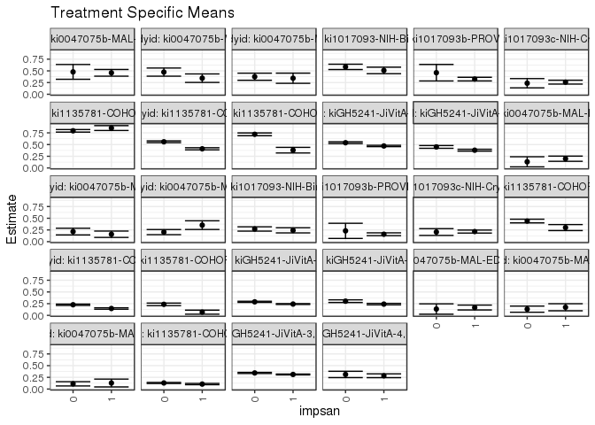

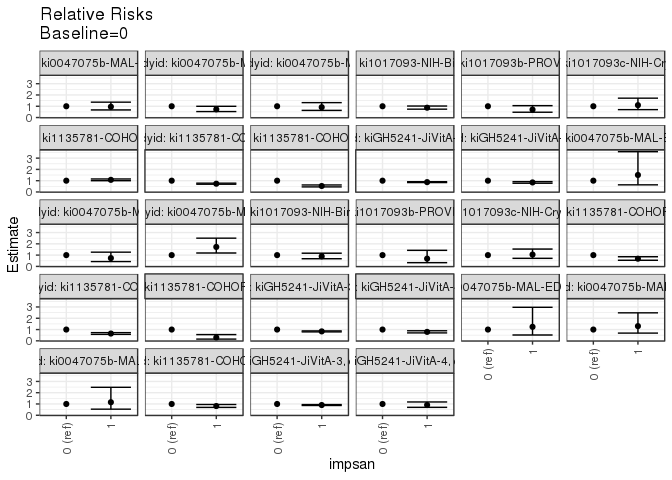

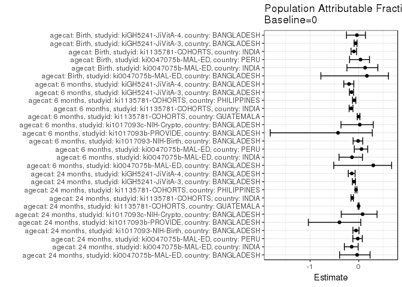

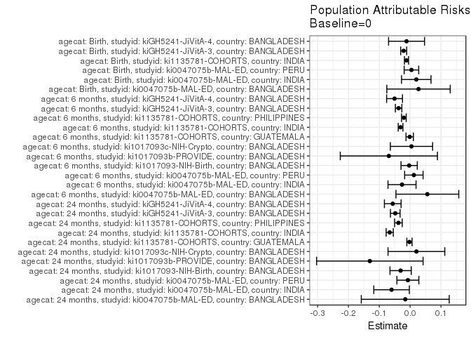

## Results Table

### Parameter: TSM

| agecat | studyid | country | intervention_level | baseline_level | estimate | ci_lower | ci_upper |
| --- | --- | --- | --- | --- | --- | --- | --- |
| Birth | ki0047075b-MAL-ED | BANGLADESH | 0 | NA | 0.1351351 | 0.0247437 | 0.2455266 |
| Birth | ki0047075b-MAL-ED | BANGLADESH | 1 | NA | 0.1675127 | 0.1152541 | 0.2197713 |
| Birth | ki0047075b-MAL-ED | INDIA | 0 | NA | 0.1326834 | 0.0671109 | 0.1982558 |
| Birth | ki0047075b-MAL-ED | INDIA | 1 | NA | 0.1728660 | 0.0977196 | 0.2480124 |
| Birth | ki0047075b-MAL-ED | PERU | 0 | NA | 0.1117021 | 0.0665842 | 0.1568201 |
| Birth | ki0047075b-MAL-ED | PERU | 1 | NA | 0.1290323 | 0.0454195 | 0.2126451 |
| Birth | ki1135781-COHORTS | INDIA | 0 | NA | 0.1301168 | 0.1185433 | 0.1416902 |
| Birth | ki1135781-COHORTS | INDIA | 1 | NA | 0.1061961 | 0.0923271 | 0.1200652 |
| Birth | kiGH5241-JiVitA-3 | BANGLADESH | 0 | NA | 0.3442387 | 0.3322220 | 0.3562555 |
| Birth | kiGH5241-JiVitA-3 | BANGLADESH | 1 | NA | 0.3118249 | 0.3027234 | 0.3209265 |
| Birth | kiGH5241-JiVitA-4 | BANGLADESH | 0 | NA | 0.3120646 | 0.2444566 | 0.3796726 |
| Birth | kiGH5241-JiVitA-4 | BANGLADESH | 1 | NA | 0.2839205 | 0.2433352 | 0.3245059 |
| 6 months | ki0047075b-MAL-ED | BANGLADESH | 0 | NA | 0.1315789 | 0.0238775 | 0.2392803 |
| 6 months | ki0047075b-MAL-ED | BANGLADESH | 1 | NA | 0.1980198 | 0.1429498 | 0.2530898 |
| 6 months | ki0047075b-MAL-ED | INDIA | 0 | NA | 0.2150847 | 0.1436346 | 0.2865348 |
| 6 months | ki0047075b-MAL-ED | INDIA | 1 | NA | 0.1580638 | 0.0898579 | 0.2262697 |
| 6 months | ki0047075b-MAL-ED | PERU | 0 | NA | 0.2046011 | 0.1498117 | 0.2593905 |
| 6 months | ki0047075b-MAL-ED | PERU | 1 | NA | 0.3528703 | 0.2602857 | 0.4454548 |
| 6 months | ki1017093-NIH-Birth | BANGLADESH | 0 | NA | 0.2713211 | 0.2253722 | 0.3172699 |
| 6 months | ki1017093-NIH-Birth | BANGLADESH | 1 | NA | 0.2421237 | 0.1872756 | 0.2969717 |
| 6 months | ki1017093b-PROVIDE | BANGLADESH | 0 | NA | 0.2307692 | 0.0686805 | 0.3928579 |
| 6 months | ki1017093b-PROVIDE | BANGLADESH | 1 | NA | 0.1585586 | 0.1281439 | 0.1889732 |
| 6 months | ki1017093c-NIH-Crypto | BANGLADESH | 0 | NA | 0.2058291 | 0.1332568 | 0.2784014 |
| 6 months | ki1017093c-NIH-Crypto | BANGLADESH | 1 | NA | 0.2157549 | 0.1833732 | 0.2481366 |
| 6 months | ki1135781-COHORTS | GUATEMALA | 0 | NA | 0.4405189 | 0.4009721 | 0.4800658 |
| 6 months | ki1135781-COHORTS | GUATEMALA | 1 | NA | 0.3007882 | 0.2368969 | 0.3646794 |
| 6 months | ki1135781-COHORTS | INDIA | 0 | NA | 0.2266897 | 0.2126075 | 0.2407719 |
| 6 months | ki1135781-COHORTS | INDIA | 1 | NA | 0.1462174 | 0.1308674 | 0.1615674 |
| 6 months | ki1135781-COHORTS | PHILIPPINES | 0 | NA | 0.2353170 | 0.2081758 | 0.2624582 |
| 6 months | ki1135781-COHORTS | PHILIPPINES | 1 | NA | 0.0683489 | 0.0251353 | 0.1115626 |
| 6 months | kiGH5241-JiVitA-3 | BANGLADESH | 0 | NA | 0.2887667 | 0.2761445 | 0.3013888 |
| 6 months | kiGH5241-JiVitA-3 | BANGLADESH | 1 | NA | 0.2414679 | 0.2322972 | 0.2506387 |
| 6 months | kiGH5241-JiVitA-4 | BANGLADESH | 0 | NA | 0.3029868 | 0.2742936 | 0.3316799 |
| 6 months | kiGH5241-JiVitA-4 | BANGLADESH | 1 | NA | 0.2402374 | 0.2242520 | 0.2562228 |
| 24 months | ki0047075b-MAL-ED | BANGLADESH | 0 | NA | 0.4779863 | 0.3202425 | 0.6357301 |
| 24 months | ki0047075b-MAL-ED | BANGLADESH | 1 | NA | 0.4580379 | 0.3866069 | 0.5294688 |
| 24 months | ki0047075b-MAL-ED | INDIA | 0 | NA | 0.4734959 | 0.3864448 | 0.5605469 |
| 24 months | ki0047075b-MAL-ED | INDIA | 1 | NA | 0.3435807 | 0.2529077 | 0.4342537 |
| 24 months | ki0047075b-MAL-ED | PERU | 0 | NA | 0.3746348 | 0.2987932 | 0.4504765 |
| 24 months | ki0047075b-MAL-ED | PERU | 1 | NA | 0.3428442 | 0.2343577 | 0.4513308 |
| 24 months | ki1017093-NIH-Birth | BANGLADESH | 0 | NA | 0.5855365 | 0.5282165 | 0.6428565 |
| 24 months | ki1017093-NIH-Birth | BANGLADESH | 1 | NA | 0.5092787 | 0.4399139 | 0.5786434 |
| 24 months | ki1017093b-PROVIDE | BANGLADESH | 0 | NA | 0.4605156 | 0.2841934 | 0.6368379 |
| 24 months | ki1017093b-PROVIDE | BANGLADESH | 1 | NA | 0.3241025 | 0.2850304 | 0.3631745 |
| 24 months | ki1017093c-NIH-Crypto | BANGLADESH | 0 | NA | 0.2360780 | 0.1372538 | 0.3349022 |
| 24 months | ki1017093c-NIH-Crypto | BANGLADESH | 1 | NA | 0.2590088 | 0.2177240 | 0.3002936 |
| 24 months | ki1135781-COHORTS | GUATEMALA | 0 | NA | 0.7935074 | 0.7661157 | 0.8208990 |
| 24 months | ki1135781-COHORTS | GUATEMALA | 1 | NA | 0.8526698 | 0.8005517 | 0.9047879 |
| 24 months | ki1135781-COHORTS | INDIA | 0 | NA | 0.5592609 | 0.5402175 | 0.5783042 |
| 24 months | ki1135781-COHORTS | INDIA | 1 | NA | 0.4094113 | 0.3869677 | 0.4318549 |
| 24 months | ki1135781-COHORTS | PHILIPPINES | 0 | NA | 0.7187285 | 0.6892515 | 0.7482055 |
| 24 months | ki1135781-COHORTS | PHILIPPINES | 1 | NA | 0.3802278 | 0.3204589 | 0.4399968 |
| 24 months | kiGH5241-JiVitA-3 | BANGLADESH | 0 | NA | 0.5390281 | 0.5201862 | 0.5578700 |
| 24 months | kiGH5241-JiVitA-3 | BANGLADESH | 1 | NA | 0.4697806 | 0.4551197 | 0.4844415 |
| 24 months | kiGH5241-JiVitA-4 | BANGLADESH | 0 | NA | 0.4494123 | 0.4197497 | 0.4790749 |
| 24 months | kiGH5241-JiVitA-4 | BANGLADESH | 1 | NA | 0.3795361 | 0.3598171 | 0.3992550 |

### Parameter: E(Y)

| agecat | studyid | country | intervention_level | baseline_level | estimate | ci_lower | ci_upper |
| --- | --- | --- | --- | --- | --- | --- | --- |
| Birth | ki0047075b-MAL-ED | BANGLADESH | NA | NA | 0.1623932 | 0.1150373 | 0.2097491 |
| Birth | ki0047075b-MAL-ED | INDIA | NA | NA | 0.1526316 | 0.1013601 | 0.2039030 |
| Birth | ki0047075b-MAL-ED | PERU | NA | NA | 0.1160000 | 0.0762256 | 0.1557744 |
| Birth | ki1135781-COHORTS | INDIA | NA | NA | 0.1182998 | 0.1091394 | 0.1274602 |
| Birth | kiGH5241-JiVitA-3 | BANGLADESH | NA | NA | 0.3233463 | 0.3156839 | 0.3310086 |
| Birth | kiGH5241-JiVitA-4 | BANGLADESH | NA | NA | 0.3004866 | 0.2649179 | 0.3360553 |
| 6 months | ki0047075b-MAL-ED | BANGLADESH | NA | NA | 0.1875000 | 0.1380164 | 0.2369836 |
| 6 months | ki0047075b-MAL-ED | INDIA | NA | NA | 0.1888412 | 0.1384789 | 0.2392035 |
| 6 months | ki0047075b-MAL-ED | PERU | NA | NA | 0.2167300 | 0.1668401 | 0.2666199 |
| 6 months | ki1017093-NIH-Birth | BANGLADESH | NA | NA | 0.2681564 | 0.2306532 | 0.3056597 |
| 6 months | ki1017093b-PROVIDE | BANGLADESH | NA | NA | 0.1617900 | 0.1318200 | 0.1917600 |
| 6 months | ki1017093c-NIH-Crypto | BANGLADESH | NA | NA | 0.2102273 | 0.1801065 | 0.2403480 |
| 6 months | ki1135781-COHORTS | GUATEMALA | NA | NA | 0.4392097 | 0.4012606 | 0.4771588 |
| 6 months | ki1135781-COHORTS | INDIA | NA | NA | 0.1957353 | 0.1847045 | 0.2067660 |
| 6 months | ki1135781-COHORTS | PHILIPPINES | NA | NA | 0.2151431 | 0.1906585 | 0.2396277 |
| 6 months | kiGH5241-JiVitA-3 | BANGLADESH | NA | NA | 0.2514677 | 0.2433332 | 0.2596023 |
| 6 months | kiGH5241-JiVitA-4 | BANGLADESH | NA | NA | 0.2525156 | 0.2383895 | 0.2666417 |
| 24 months | ki0047075b-MAL-ED | BANGLADESH | NA | NA | 0.4622642 | 0.3949918 | 0.5295365 |
| 24 months | ki0047075b-MAL-ED | INDIA | NA | NA | 0.4133333 | 0.3488467 | 0.4778200 |
| 24 months | ki0047075b-MAL-ED | PERU | NA | NA | 0.3673469 | 0.2996839 | 0.4350100 |
| 24 months | ki1017093-NIH-Birth | BANGLADESH | NA | NA | 0.5547786 | 0.5076945 | 0.6018626 |
| 24 months | ki1017093b-PROVIDE | BANGLADESH | NA | NA | 0.3298611 | 0.2914318 | 0.3682904 |
| 24 months | ki1017093c-NIH-Crypto | BANGLADESH | NA | NA | 0.2564612 | 0.2182616 | 0.2946608 |
| 24 months | ki1135781-COHORTS | GUATEMALA | NA | NA | 0.7912946 | 0.7646707 | 0.8179186 |
| 24 months | ki1135781-COHORTS | INDIA | NA | NA | 0.4930741 | 0.4770789 | 0.5090692 |
| 24 months | ki1135781-COHORTS | PHILIPPINES | NA | NA | 0.6808081 | 0.6517553 | 0.7098609 |
| 24 months | kiGH5241-JiVitA-3 | BANGLADESH | NA | NA | 0.4908172 | 0.4777026 | 0.5039317 |
| 24 months | kiGH5241-JiVitA-4 | BANGLADESH | NA | NA | 0.3930960 | 0.3759134 | 0.4102786 |

### Parameter: RR

| agecat | studyid | country | intervention_level | baseline_level | estimate | ci_lower | ci_upper |
| --- | --- | --- | --- | --- | --- | --- | --- |
| Birth | ki0047075b-MAL-ED | BANGLADESH | 0 | 0 | 1.0000000 | 1.0000000 | 1.0000000 |
| Birth | ki0047075b-MAL-ED | BANGLADESH | 1 | 0 | 1.2395939 | 0.5170294 | 2.9719647 |
| Birth | ki0047075b-MAL-ED | INDIA | 0 | 0 | 1.0000000 | 1.0000000 | 1.0000000 |
| Birth | ki0047075b-MAL-ED | INDIA | 1 | 0 | 1.3028461 | 0.6834136 | 2.4837202 |
| Birth | ki0047075b-MAL-ED | PERU | 0 | 0 | 1.0000000 | 1.0000000 | 1.0000000 |
| Birth | ki0047075b-MAL-ED | PERU | 1 | 0 | 1.1551459 | 0.5382944 | 2.4788706 |
| Birth | ki1135781-COHORTS | INDIA | 0 | 0 | 1.0000000 | 1.0000000 | 1.0000000 |
| Birth | ki1135781-COHORTS | INDIA | 1 | 0 | 0.8161603 | 0.6971777 | 0.9554487 |
| Birth | kiGH5241-JiVitA-3 | BANGLADESH | 0 | 0 | 1.0000000 | 1.0000000 | 1.0000000 |
| Birth | kiGH5241-JiVitA-3 | BANGLADESH | 1 | 0 | 0.9058391 | 0.8674996 | 0.9458731 |
| Birth | kiGH5241-JiVitA-4 | BANGLADESH | 0 | 0 | 1.0000000 | 1.0000000 | 1.0000000 |
| Birth | kiGH5241-JiVitA-4 | BANGLADESH | 1 | 0 | 0.9098133 | 0.7016914 | 1.1796641 |
| 6 months | ki0047075b-MAL-ED | BANGLADESH | 0 | 0 | 1.0000000 | 1.0000000 | 1.0000000 |
| 6 months | ki0047075b-MAL-ED | BANGLADESH | 1 | 0 | 1.5049505 | 0.6339883 | 3.5724256 |
| 6 months | ki0047075b-MAL-ED | INDIA | 0 | 0 | 1.0000000 | 1.0000000 | 1.0000000 |
| 6 months | ki0047075b-MAL-ED | INDIA | 1 | 0 | 0.7348910 | 0.4279783 | 1.2618976 |
| 6 months | ki0047075b-MAL-ED | PERU | 0 | 0 | 1.0000000 | 1.0000000 | 1.0000000 |
| 6 months | ki0047075b-MAL-ED | PERU | 1 | 0 | 1.7246741 | 1.1883672 | 2.5030149 |
| 6 months | ki1017093-NIH-Birth | BANGLADESH | 0 | 0 | 1.0000000 | 1.0000000 | 1.0000000 |
| 6 months | ki1017093-NIH-Birth | BANGLADESH | 1 | 0 | 0.8923880 | 0.6806376 | 1.1700152 |
| 6 months | ki1017093b-PROVIDE | BANGLADESH | 0 | 0 | 1.0000000 | 1.0000000 | 1.0000000 |
| 6 months | ki1017093b-PROVIDE | BANGLADESH | 1 | 0 | 0.6870871 | 0.3317411 | 1.4230635 |
| 6 months | ki1017093c-NIH-Crypto | BANGLADESH | 0 | 0 | 1.0000000 | 1.0000000 | 1.0000000 |
| 6 months | ki1017093c-NIH-Crypto | BANGLADESH | 1 | 0 | 1.0482236 | 0.7154379 | 1.5358046 |
| 6 months | ki1135781-COHORTS | GUATEMALA | 0 | 0 | 1.0000000 | 1.0000000 | 1.0000000 |
| 6 months | ki1135781-COHORTS | GUATEMALA | 1 | 0 | 0.6828042 | 0.5440131 | 0.8570044 |
| 6 months | ki1135781-COHORTS | INDIA | 0 | 0 | 1.0000000 | 1.0000000 | 1.0000000 |
| 6 months | ki1135781-COHORTS | INDIA | 1 | 0 | 0.6450112 | 0.5715552 | 0.7279078 |
| 6 months | ki1135781-COHORTS | PHILIPPINES | 0 | 0 | 1.0000000 | 1.0000000 | 1.0000000 |
| 6 months | ki1135781-COHORTS | PHILIPPINES | 1 | 0 | 0.2904547 | 0.1527110 | 0.5524418 |
| 6 months | kiGH5241-JiVitA-3 | BANGLADESH | 0 | 0 | 1.0000000 | 1.0000000 | 1.0000000 |
| 6 months | kiGH5241-JiVitA-3 | BANGLADESH | 1 | 0 | 0.8362044 | 0.7927847 | 0.8820021 |
| 6 months | kiGH5241-JiVitA-4 | BANGLADESH | 0 | 0 | 1.0000000 | 1.0000000 | 1.0000000 |
| 6 months | kiGH5241-JiVitA-4 | BANGLADESH | 1 | 0 | 0.7928973 | 0.7046578 | 0.8921865 |
| 24 months | ki0047075b-MAL-ED | BANGLADESH | 0 | 0 | 1.0000000 | 1.0000000 | 1.0000000 |
| 24 months | ki0047075b-MAL-ED | BANGLADESH | 1 | 0 | 0.9582657 | 0.6733411 | 1.3637561 |
| 24 months | ki0047075b-MAL-ED | INDIA | 0 | 0 | 1.0000000 | 1.0000000 | 1.0000000 |
| 24 months | ki0047075b-MAL-ED | INDIA | 1 | 0 | 0.7256256 | 0.5288697 | 0.9955807 |
| 24 months | ki0047075b-MAL-ED | PERU | 0 | 0 | 1.0000000 | 1.0000000 | 1.0000000 |
| 24 months | ki0047075b-MAL-ED | PERU | 1 | 0 | 0.9151424 | 0.6334017 | 1.3222031 |
| 24 months | ki1017093-NIH-Birth | BANGLADESH | 0 | 0 | 1.0000000 | 1.0000000 | 1.0000000 |
| 24 months | ki1017093-NIH-Birth | BANGLADESH | 1 | 0 | 0.8697641 | 0.7411956 | 1.0206343 |
| 24 months | ki1017093b-PROVIDE | BANGLADESH | 0 | 0 | 1.0000000 | 1.0000000 | 1.0000000 |
| 24 months | ki1017093b-PROVIDE | BANGLADESH | 1 | 0 | 0.7037817 | 0.4710660 | 1.0514634 |
| 24 months | ki1017093c-NIH-Crypto | BANGLADESH | 0 | 0 | 1.0000000 | 1.0000000 | 1.0000000 |
| 24 months | ki1017093c-NIH-Crypto | BANGLADESH | 1 | 0 | 1.0971324 | 0.7012738 | 1.7164472 |
| 24 months | ki1135781-COHORTS | GUATEMALA | 0 | 0 | 1.0000000 | 1.0000000 | 1.0000000 |
| 24 months | ki1135781-COHORTS | GUATEMALA | 1 | 0 | 1.0745582 | 1.0025435 | 1.1517458 |
| 24 months | ki1135781-COHORTS | INDIA | 0 | 0 | 1.0000000 | 1.0000000 | 1.0000000 |
| 24 months | ki1135781-COHORTS | INDIA | 1 | 0 | 0.7320578 | 0.6878488 | 0.7791083 |
| 24 months | ki1135781-COHORTS | PHILIPPINES | 0 | 0 | 1.0000000 | 1.0000000 | 1.0000000 |
| 24 months | ki1135781-COHORTS | PHILIPPINES | 1 | 0 | 0.5290284 | 0.4504821 | 0.6212701 |
| 24 months | kiGH5241-JiVitA-3 | BANGLADESH | 0 | 0 | 1.0000000 | 1.0000000 | 1.0000000 |
| 24 months | kiGH5241-JiVitA-3 | BANGLADESH | 1 | 0 | 0.8715327 | 0.8342308 | 0.9105026 |
| 24 months | kiGH5241-JiVitA-4 | BANGLADESH | 0 | 0 | 1.0000000 | 1.0000000 | 1.0000000 |
| 24 months | kiGH5241-JiVitA-4 | BANGLADESH | 1 | 0 | 0.8445164 | 0.7777611 | 0.9170014 |

### Parameter: PAR

| agecat | studyid | country | intervention_level | baseline_level | estimate | ci_lower | ci_upper |
| --- | --- | --- | --- | --- | --- | --- | --- |
| Birth | ki0047075b-MAL-ED | BANGLADESH | 0 | NA | 0.0272580 | -0.0755772 | 0.1300932 |
| Birth | ki0047075b-MAL-ED | INDIA | 0 | NA | 0.0199482 | -0.0278435 | 0.0677400 |
| Birth | ki0047075b-MAL-ED | PERU | 0 | NA | 0.0042979 | -0.0192827 | 0.0278785 |
| Birth | ki1135781-COHORTS | INDIA | 0 | NA | -0.0118169 | -0.0185157 | -0.0051181 |
| Birth | kiGH5241-JiVitA-3 | BANGLADESH | 0 | NA | -0.0208925 | -0.0305904 | -0.0111945 |
| Birth | kiGH5241-JiVitA-4 | BANGLADESH | 0 | NA | -0.0115780 | -0.0698760 | 0.0467199 |
| 6 months | ki0047075b-MAL-ED | BANGLADESH | 0 | NA | 0.0559211 | -0.0459368 | 0.1577789 |
| 6 months | ki0047075b-MAL-ED | INDIA | 0 | NA | -0.0262435 | -0.0717034 | 0.0192164 |
| 6 months | ki0047075b-MAL-ED | PERU | 0 | NA | 0.0121289 | -0.0177804 | 0.0420383 |
| 6 months | ki1017093-NIH-Birth | BANGLADESH | 0 | NA | -0.0031646 | -0.0295698 | 0.0232405 |
| 6 months | ki1017093b-PROVIDE | BANGLADESH | 0 | NA | -0.0689792 | -0.2265213 | 0.0885629 |
| 6 months | ki1017093c-NIH-Crypto | BANGLADESH | 0 | NA | 0.0043982 | -0.0640963 | 0.0728926 |
| 6 months | ki1135781-COHORTS | GUATEMALA | 0 | NA | -0.0013092 | -0.0132087 | 0.0105903 |
| 6 months | ki1135781-COHORTS | INDIA | 0 | NA | -0.0309544 | -0.0385893 | -0.0233195 |
| 6 months | ki1135781-COHORTS | PHILIPPINES | 0 | NA | -0.0201739 | -0.0276508 | -0.0126970 |
| 6 months | kiGH5241-JiVitA-3 | BANGLADESH | 0 | NA | -0.0372989 | -0.0478063 | -0.0267915 |
| 6 months | kiGH5241-JiVitA-4 | BANGLADESH | 0 | NA | -0.0504711 | -0.0761652 | -0.0247771 |
| 24 months | ki0047075b-MAL-ED | BANGLADESH | 0 | NA | -0.0157222 | -0.1583065 | 0.1268621 |
| 24 months | ki0047075b-MAL-ED | INDIA | 0 | NA | -0.0601625 | -0.1178090 | -0.0025160 |
| 24 months | ki0047075b-MAL-ED | PERU | 0 | NA | -0.0072879 | -0.0428927 | 0.0283169 |
| 24 months | ki1017093-NIH-Birth | BANGLADESH | 0 | NA | -0.0307580 | -0.0652791 | 0.0037632 |
| 24 months | ki1017093b-PROVIDE | BANGLADESH | 0 | NA | -0.1306545 | -0.3033371 | 0.0420280 |
| 24 months | ki1017093c-NIH-Crypto | BANGLADESH | 0 | NA | 0.0203832 | -0.0716714 | 0.1124379 |
| 24 months | ki1135781-COHORTS | GUATEMALA | 0 | NA | -0.0022127 | -0.0107133 | 0.0062878 |
| 24 months | ki1135781-COHORTS | INDIA | 0 | NA | -0.0661868 | -0.0777420 | -0.0546316 |
| 24 months | ki1135781-COHORTS | PHILIPPINES | 0 | NA | -0.0379205 | -0.0502502 | -0.0255907 |
| 24 months | kiGH5241-JiVitA-3 | BANGLADESH | 0 | NA | -0.0482109 | -0.0638688 | -0.0325531 |
| 24 months | kiGH5241-JiVitA-4 | BANGLADESH | 0 | NA | -0.0563163 | -0.0833493 | -0.0292833 |

### Parameter: PAF

| agecat | studyid | country | intervention_level | baseline_level | estimate | ci_lower | ci_upper |
| --- | --- | --- | --- | --- | --- | --- | --- |
| Birth | ki0047075b-MAL-ED | BANGLADESH | 0 | NA | 0.1678521 | -0.7783643 | 0.6106140 |
| Birth | ki0047075b-MAL-ED | INDIA | 0 | NA | 0.1306952 | -0.2427722 | 0.3919313 |
| Birth | ki0047075b-MAL-ED | PERU | 0 | NA | 0.0370506 | -0.1889133 | 0.2200680 |
| Birth | ki1135781-COHORTS | INDIA | 0 | NA | -0.0998896 | -0.1582119 | -0.0445042 |
| Birth | kiGH5241-JiVitA-3 | BANGLADESH | 0 | NA | -0.0646133 | -0.0951607 | -0.0349180 |
| Birth | kiGH5241-JiVitA-4 | BANGLADESH | 0 | NA | -0.0385309 | -0.2520357 | 0.1385658 |
| 6 months | ki0047075b-MAL-ED | BANGLADESH | 0 | NA | 0.2982456 | -0.5135140 | 0.6746253 |
| 6 months | ki0047075b-MAL-ED | INDIA | 0 | NA | -0.1389713 | -0.4055341 | 0.0770373 |
| 6 months | ki0047075b-MAL-ED | PERU | 0 | NA | 0.0559633 | -0.0914213 | 0.1834451 |
| 6 months | ki1017093-NIH-Birth | BANGLADESH | 0 | NA | -0.0118014 | -0.1152297 | 0.0820347 |
| 6 months | ki1017093b-PROVIDE | BANGLADESH | 0 | NA | -0.4263502 | -1.8201542 | 0.2785944 |
| 6 months | ki1017093c-NIH-Crypto | BANGLADESH | 0 | NA | 0.0209210 | -0.3653325 | 0.2979032 |
| 6 months | ki1135781-COHORTS | GUATEMALA | 0 | NA | -0.0029808 | -0.0304495 | 0.0237556 |
| 6 months | ki1135781-COHORTS | INDIA | 0 | NA | -0.1581444 | -0.1978642 | -0.1197416 |
| 6 months | ki1135781-COHORTS | PHILIPPINES | 0 | NA | -0.0937696 | -0.1283201 | -0.0602771 |
| 6 months | kiGH5241-JiVitA-3 | BANGLADESH | 0 | NA | -0.1483248 | -0.1916598 | -0.1065658 |
| 6 months | kiGH5241-JiVitA-4 | BANGLADESH | 0 | NA | -0.1998733 | -0.3073375 | -0.1012429 |
| 24 months | ki0047075b-MAL-ED | BANGLADESH | 0 | NA | -0.0340112 | -0.3934453 | 0.2327082 |
| 24 months | ki0047075b-MAL-ED | INDIA | 0 | NA | -0.1455545 | -0.2956145 | -0.0128746 |
| 24 months | ki0047075b-MAL-ED | PERU | 0 | NA | -0.0198393 | -0.1216729 | 0.0727491 |
| 24 months | ki1017093-NIH-Birth | BANGLADESH | 0 | NA | -0.0554419 | -0.1199144 | 0.0053190 |
| 24 months | ki1017093b-PROVIDE | BANGLADESH | 0 | NA | -0.3960895 | -1.0352479 | 0.0423447 |
| 24 months | ki1017093c-NIH-Crypto | BANGLADESH | 0 | NA | 0.0794788 | -0.3593744 | 0.3766550 |
| 24 months | ki1135781-COHORTS | GUATEMALA | 0 | NA | -0.0027963 | -0.0136035 | 0.0078957 |
| 24 months | ki1135781-COHORTS | INDIA | 0 | NA | -0.1342330 | -0.1586354 | -0.1103445 |
| 24 months | ki1135781-COHORTS | PHILIPPINES | 0 | NA | -0.0556992 | -0.0745449 | -0.0371840 |
| 24 months | kiGH5241-JiVitA-3 | BANGLADESH | 0 | NA | -0.0982259 | -0.1311114 | -0.0662964 |
| 24 months | kiGH5241-JiVitA-4 | BANGLADESH | 0 | NA | -0.1432635 | -0.2154809 | -0.0753368 |